# RplotterPkg::histogram_plot() demos

Rick Dean

12/20/2019

```r
library(data.table)
library(rlang)
library(grid)
library(gtable)
library(ggplot2)
library(socviz)
library(tidyr)
library(dplyr)
library(RplotterPkg)
```

# Demos

## 1 Introduction

The following R scripts provides some histogram plot examples of [RplotterPkg::create_histogram_plot()](https://github.com/deandevl/RplotterPkg).

## 2 Setting the aes_x aesthetic.

Task: Plot a histogram showing counts for a binned continuous variable. The dataset `ggplot2::midwest` has a continuous variable called *area*. Show the count distribution of *area* for 437 counties from the `ggplot2::midwest` dataset by setting `aes_x = “area”` . Accept ggplot2’s default *binwidth* along with scaling of the x and y axis’.

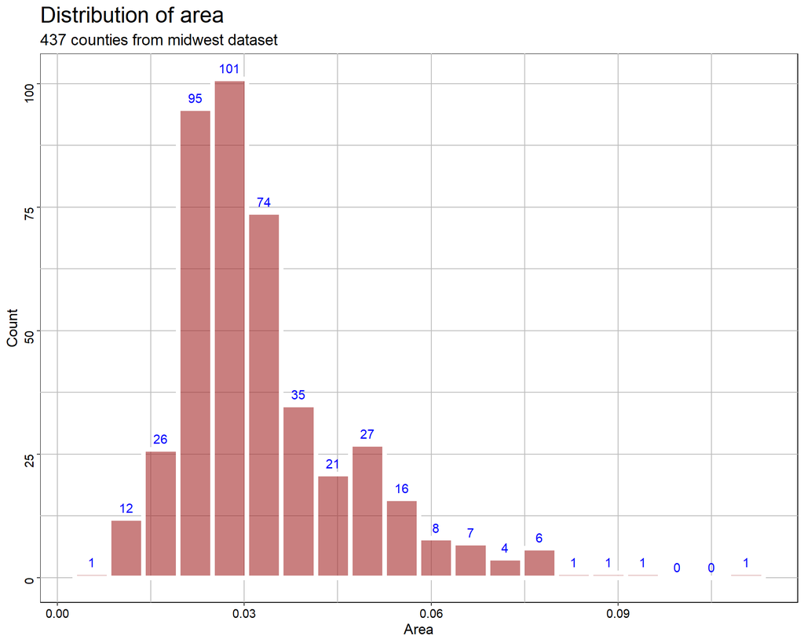

```r
RplotterPkg::create_histogram_plot(
  df = ggplot2::midwest,
  aes_x = "area",
  title = "Distribution of area",
  subtitle = "437 counties from midwest dataset",
  x_title = "Area",
  bar_color = "white",
  bar_size = 2.0,
  bar_fill = "brown",
  bar_alpha = 0.6,
  bar_labels = TRUE,
  bar_label_size = 4,
  bar_label_color = "blue"
)
```

Task: Repeat the above plot with `binwidth = 0.01`, new x axis scaling and plot the observations along the axis margin.

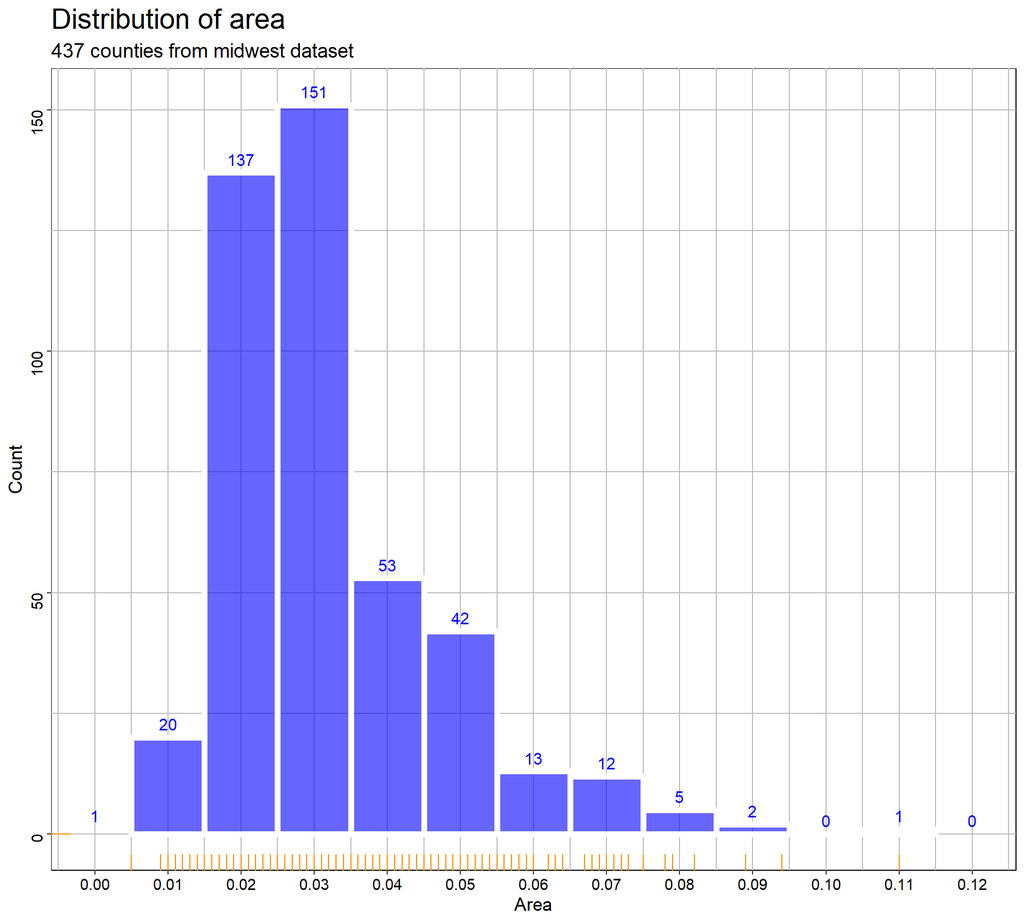

```r
RplotterPkg::create_histogram_plot(
  df = ggplot2::midwest,
  aes_x = "area",
  binwidth = 0.01,
  x_limits = c(0.0, 0.12),
  x_major_breaks = seq(0.0, 0.12, 0.01),
  title = "Distribution of area",
  subtitle = "437 counties from midwest dataset",
  x_title = "Area",
  bar_color = "white",
  bar_size = 2.0,
  bar_fill = "blue",
  bar_alpha = 0.6,
  bar_labels = TRUE,
  bar_label_size = 4,
  bar_label_color = "blue",
  plot_obs = TRUE,
  plot_obs_color = "darkorange",
  silent_NA_warning = TRUE
)
```

## 2 Setting the aes_x and aes_fill aesthetics.

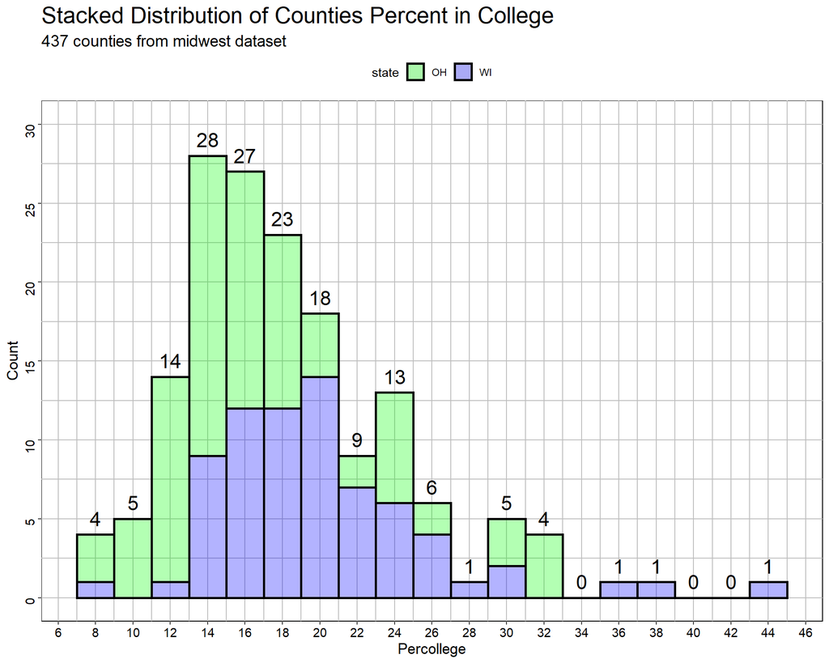

```r
oh_wis_df <- ggplot2::midwest %>%
  filter(state %in% c("OH","WI")) %>%
  select(state,percollege)

create_histogram_plot(
  df = oh_wis_df,
  aes_x = "percollege",
  aes_fill = "state",
  binwidth = 2.0,
  x_major_breaks = seq(0,50,2),
  y_limits = c(0, 30),
  y_major_breaks = seq(from = 0, to = 30, by =5),
  x_title = "Percollege",
  bar_alpha = 0.3,
  title = "Stacked Distribution of Counties Percent in College",
  subtitle = "437 counties from midwest dataset",
  palette_colors = c(OH = "green", WI = "blue"),
  bar_labels = TRUE
)
```

Task: Repeat the above midwest distribution where the bars overlap `position = “identity”`.

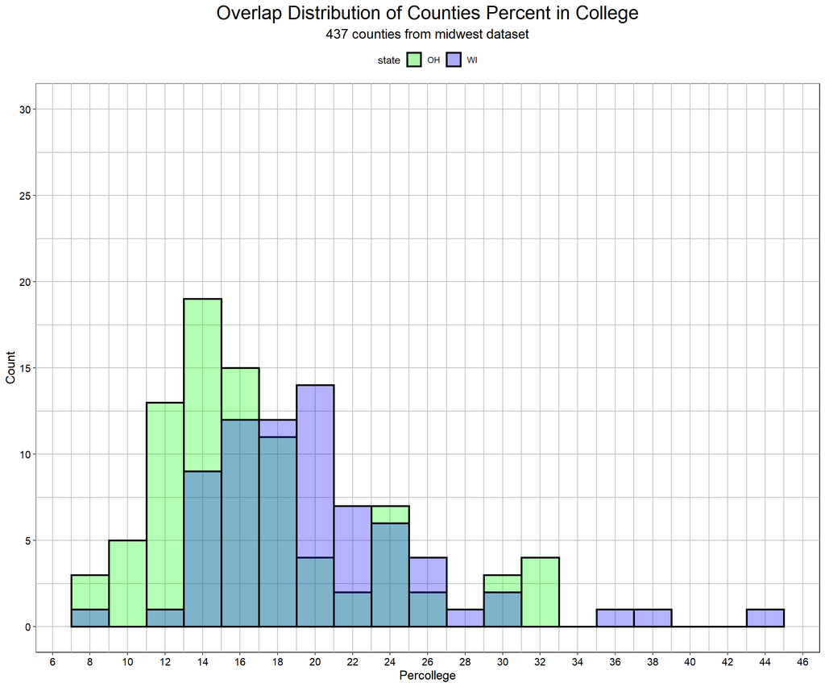

```r
oh_wis_plot <- create_histogram_plot(
  df = oh_wis_df,
  aes_x = "percollege",
  aes_fill = "state",
  position = "identity",
  binwidth = 2.0,
  x_major_breaks = seq(0,50,2),
  y_limits = c(0, 30),
  y_major_breaks = seq(from = 0, to = 30, by =5),
  x_title = "Percollege",
  bar_alpha = 0.3,
  title = "Overlap Distribution of Counties Percent in College",
  subtitle = "437 counties from midwest dataset",
  palette_colors = c(OH = "green", WI = "blue"),
  center_titles = TRUE,
  rot_y_tic_label = TRUE
)
oh_wis_plot
```

Task: Repeat the above midwest distribution where the bars are side by side `position = “dodge”`.

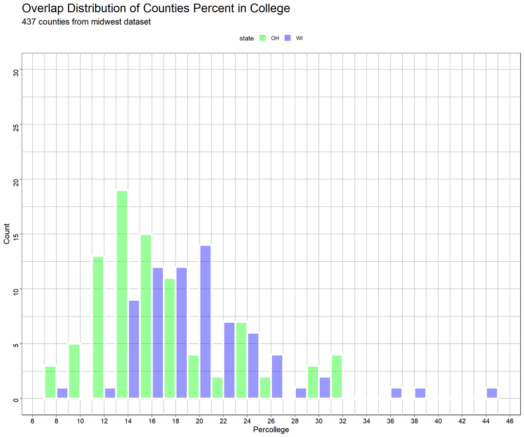

```r
oh_wis_plot <- create_histogram_plot(
  df = oh_wis_df,
  aes_x = "percollege",
  aes_fill = "state",
  position = "dodge",
  binwidth = 2.0,
  x_major_breaks = seq(0,50,2),
  y_limits = c(0, 30),
  y_major_breaks = seq(from = 0, to = 30, by =5),
  x_title = "Percollege",
  bar_color = "white",
  bar_size = 1.5,
  title = "Overlap Distribution of Counties Percent in College",
  subtitle = "437 counties from midwest dataset",
  palette_colors = c(OH = "green", WI = "blue")
)
oh_wis_plot
```

## 3 Setting the aesthetic aes_x and factor_var.

Task: From the `datasets::trees` dataset compare distributions for the continuous variables *Girth*, *Height*, and *Volume*. Create a data frame that converts the variables from raw values to z-scores.

```r
trees_z_df <- datasets::trees %>%
  transmute(
    Girth_z = (Girth - mean(Girth))/sd(Girth),
    Height_z = (Height - mean(Height))/sd(Height),
    Volume_z = (Volume - mean(Volume))/sd(Volume)
  )
trees_z_df <- tidyr::pivot_longer(data = trees_z_df, cols = c(Girth_z, Height_z, Volume_z),
                                  names_to = "Measure", values_to = "Z_Score")
str(trees_z_df)
## tibble [93 x 2] (S3: tbl_df/tbl/data.frame)
##  $ Measure: chr [1:93] "Girth_z" "Height_z" "Volume_z" "Girth_z" ...
##  $ Z_Score: num [1:93] -1.577 -0.942 -1.209 -1.481 -1.726 ...
```

Task: Plot their individual z score counts by setting *factor_x* to “Z_Score” variable from *trees_z_df*. Show the distributions in individual panels by using `RplotterPkg::multi_histogram_plot()` and setting *factor_var* = “Measure” and *columns* = 3 which will show all 3 levels of “Measure” in one row. Set the x axis scaling breaks at 0.5.

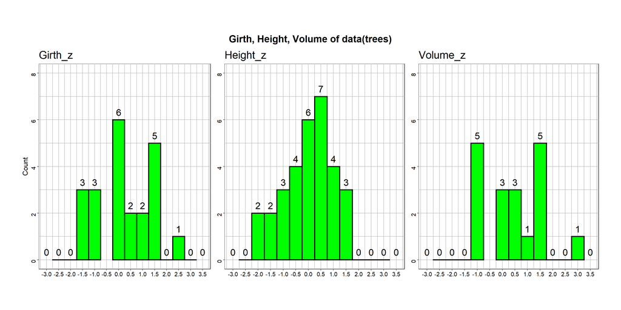

```r
tree_plot <- multi_histogram_plot(
  df = trees_z_df,
  factor_var = "Measure",
  factor_x = "Z_Score",
  columns = 3,
  title = "Girth, Height, Volume of data(trees)",
  bar_color = "black",
  bar_fill = "green",
  binwidth = 0.5,
  x_limits = c(-3,3.5),
  x_major_breaks = seq(from = -3, to = 3.5, by = 0.5),
  y_limits = c(0,8),
  col_width = 5,
  row_height = 6,
  bar_labels = TRUE,
  silent_NA_warning = TRUE
)
```

Task: From the `socviz::gss_sm` dataset find the distribution of *age* and *race* across *marital* status.

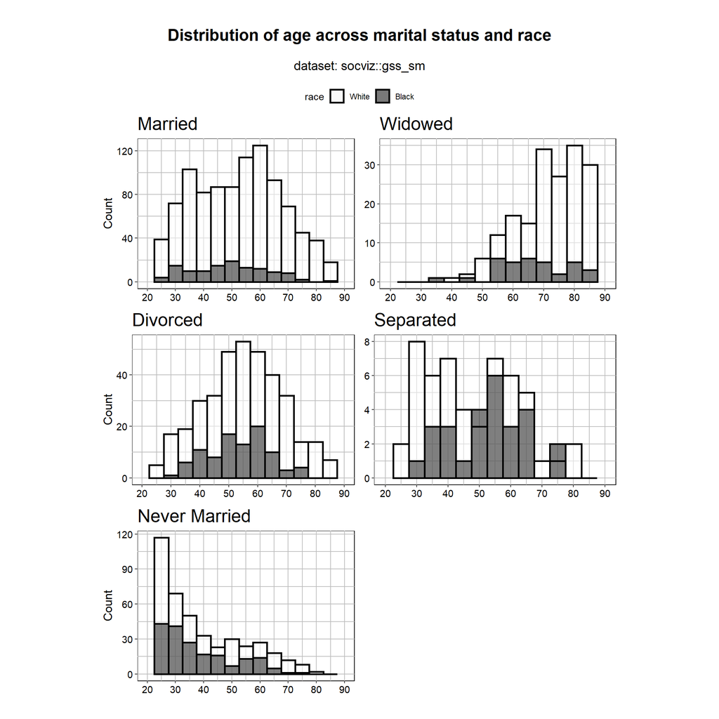

```r
white_black_df <- socviz::gss_sm %>%
  filter(race %in% c("White", "Black"))
age_race_plot <- multi_histogram_plot(
  df = white_black_df,
  factor_var = "marital",
  factor_x = "age",
  title = "Distribution of age across marital status and race",
  subtitle = "dataset: socviz::gss_sm",
  rot_y_tic_label = TRUE,
  aes_fill = "race",
  position = "identity",
  x_limits = c(20,90),
  x_major_breaks = seq(20,90,10),
  palette_colors = c("white", "black"),
  bar_alpha = 0.5,
  binwidth = 5,
  row_height = 3,
  silent_NA_warning = TRUE
)
```

Task: From the `ggplot2::midwest` data set, get histograms for some of its numeric variables.

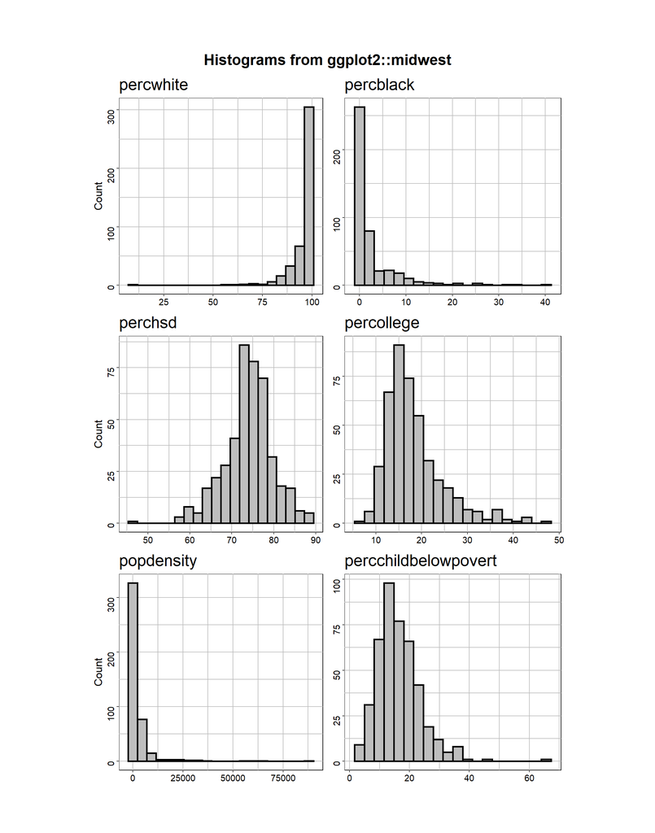

```r
midwest_histos <- RplotterPkg::multi_histogram_plot(
  df = ggplot2::midwest,
  variables = c("percwhite", "percblack", "perchsd", "percollege", "popdensity",  "percchildbelowpovert"),
  title = "Histograms from ggplot2::midwest"
)
```